# Titanic Visualizations

This is an R Notebook that uses R to analyze Titanic data from the Udacity Machine Learning course in parallel to the course material. It will serve as an interesting comparision to the code required to analyze data through Python.

# Import Data

```r
library(here)
in_file <- here('3_Titanic/titanic_data.csv')
full_data <- read.csv(in_file)
head(full_data)
```

|  | PassengerId | Survived | Pclass | Name | Sex | Age | SibSp | Parch | Ticket | Fare | Cabin | Embarked |
| --- | --- | --- | --- | --- | --- | --- | --- | --- | --- | --- | --- | --- |
| 1 | 1 | 0 | 3 | Braund, Mr. Owen Harris | male | 22 | 1 | 0 | A/5 21171 | 7.2500 |  | S |
| 2 | 2 | 1 | 1 | Cumings, Mrs. John Bradley (Florence Briggs Thayer) | female | 38 | 1 | 0 | PC 17599 | 71.2833 | C85 | C |
| 3 | 3 | 1 | 3 | Heikkinen, Miss. Laina | female | 26 | 0 | 0 | STON/O2. 3101282 | 7.9250 |  | S |
| 4 | 4 | 1 | 1 | Futrelle, Mrs. Jacques Heath (Lily May Peel) | female | 35 | 1 | 0 | 113803 | 53.1000 | C123 | S |
| 5 | 5 | 0 | 3 | Allen, Mr. William Henry | male | 35 | 0 | 0 | 373450 | 8.0500 |  | S |
| 6 | 6 | 0 | 3 | Moran, Mr. James | male | NA | 0 | 0 | 330877 | 8.4583 |  | Q |

# Manipulate Data

We remove the surival feature from the dataset and move it to its own separate variable, outcomes, as it is the feature we are trying to predict from the data.

```r
library(dplyr)
outcomes <- factor(full_data$Survived)
data <- full_data %>%
  select(-Survived)
head(data)
```

|  | PassengerId | Pclass | Name | Sex | Age | SibSp | Parch | Ticket | Fare | Cabin | Embarked |
| --- | --- | --- | --- | --- | --- | --- | --- | --- | --- | --- | --- |
| 1 | 1 | 3 | Braund, Mr. Owen Harris | male | 22 | 1 | 0 | A/5 21171 | 7.2500 |  | S |
| 2 | 2 | 1 | Cumings, Mrs. John Bradley (Florence Briggs Thayer) | female | 38 | 1 | 0 | PC 17599 | 71.2833 | C85 | C |
| 3 | 3 | 3 | Heikkinen, Miss. Laina | female | 26 | 0 | 0 | STON/O2. 3101282 | 7.9250 |  | S |
| 4 | 4 | 1 | Futrelle, Mrs. Jacques Heath (Lily May Peel) | female | 35 | 1 | 0 | 113803 | 53.1000 | C123 | S |
| 5 | 5 | 3 | Allen, Mr. William Henry | male | 35 | 0 | 0 | 373450 | 8.0500 |  | S |
| 6 | 6 | 3 | Moran, Mr. James | male | NA | 0 | 0 | 330877 | 8.4583 |  | Q |

## Accuracy

Let’s test a sample prediction with the first 5 results, predicting they all have surivived

```r
accuracy_score(rep(1,5), outcomes[1:5])
```

```
[1] "Predictions have an accuracy of 60%"
```

# Making Predictions

Since most people did not survive the Titanic, our null hyopthesis for any model will be based on a model that assumes no one survived. Any model that does not beat this naive model is a bad model.

```r
predictions_0 <- function(data) {
  predictions = rep(0, nrow(data))
}
predictions <- predictions_0(data)
accuracy_score(predictions, outcomes)
```

```
[1] "Predictions have an accuracy of 61.6%"
```

## Effect of Sex

Rather than create a function to plot based on a feature, we will use the rather intuitive ggplot2 syntax to quickly build plots.

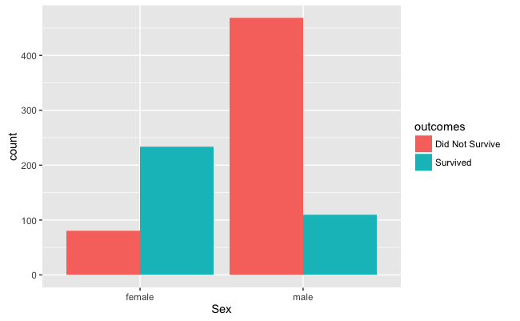

```r
survival_labs <- c("Did Not Survive", "Survived")
ggplot(data = data, aes(Sex, fill=outcomes)) +
  geom_bar(position="dodge") +
  scale_fill_discrete(labels = survival_labs)
```

Since we know more females as a percentage survived than males, our next model will perform a simple prediction based on sex.

```r
predictions_1 <- function(data) {
  as.numeric(data$Sex == "female")
}
accuracy_score(predictions_1(data), outcomes)
```

```
[1] "Predictions have an accuracy of 78.7%"
```